# Praca domowa 2

## Dane

Dane wykorzystane w Pracy domowej 2 opisują wycenę nieruchmości. Każda obserwacja jest pewną nieruchmością, która posiada informacje takie jak powierzchnia, liczba pokoi, liczba łazienek i wiele więcj. Opis wszystkich kolumn w pliku `README.md`.

## Zadanie 1

Jak wygląda rozkład ceny nieruchomości w poszczególnych kodach pocztowych na przestrzeni lat? Rozważamy kody pocztowe, które mają więcej niż 280 posiadłości.

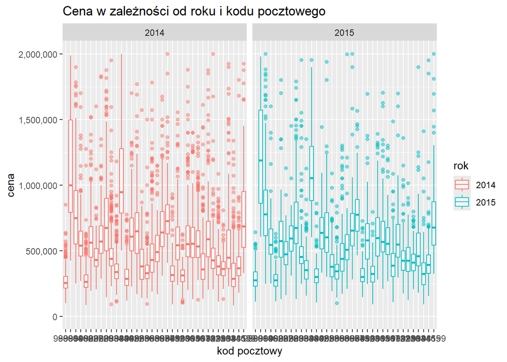

```r
z_1 <- df %>%
  group_by(zipcode) %>%
  summarise(flats_qounted = n()) %>%
  filter(flats_qounted > 280)

z_1_1 <- z_1 %>%
  left_join(df, by = 'zipcode') %>%
  mutate(year = substr(date, 1, 4))

ggplot(z_1_1, aes(x = factor(zipcode), y = price, color = year)) +
  geom_boxplot(alpha = 0.5) +
  facet_grid(~year) +
    labs(title = "Cena w zależności od roku i kodu pocztowego",
       x = "kod pocztowy",
       y = "cena",
       color = "rok") +
  scale_y_continuous(labels = scales::comma, limits = c(0, 2000000))
```

**Komentarz:**

## Zadanie 2

Czy jest różnica w rozkładzie ceny nierchomości od powierzchni mieszkalnej uwzględniając podział na nieruchomości z piwnicą i bez?

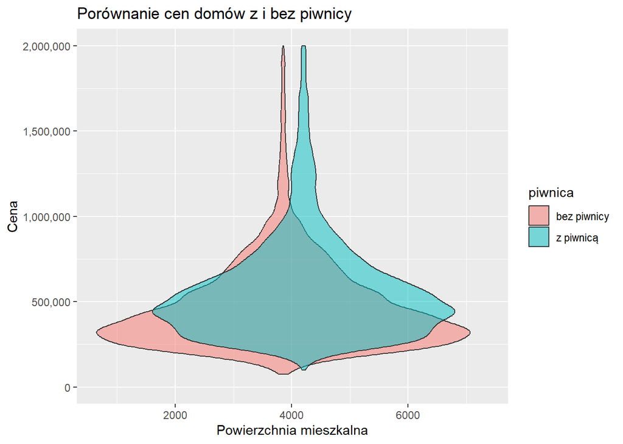

```r
z_2_combined <- df %>%
  mutate(piwnica = ifelse(sqft_basement == 0, "bez piwnicy", "z piwnicą")) %>%
  select(price, sqft_living, piwnica)

# Tworzenie jednego wykresu z podziałem na "z piwnicą" i "bez piwnicy"
plot_combined <- ggplot(z_2_combined, aes(x = sqft_living, y = price, fill = piwnica)) +
  geom_violin(alpha = 0.5) +
  labs(title = "Porównanie cen domów z i bez piwnicy",
       x = "Powierzchnia mieszkalna",
       y = "Cena") +
  scale_y_continuous(labels = scales::comma, limits = c(0, 2000000))

plot_combined
```

**Komentarz:**

## Zadanie 3

Jaka jest zależność pomiędzy jakością wykończenia nieruchomości a liczbą pięter?

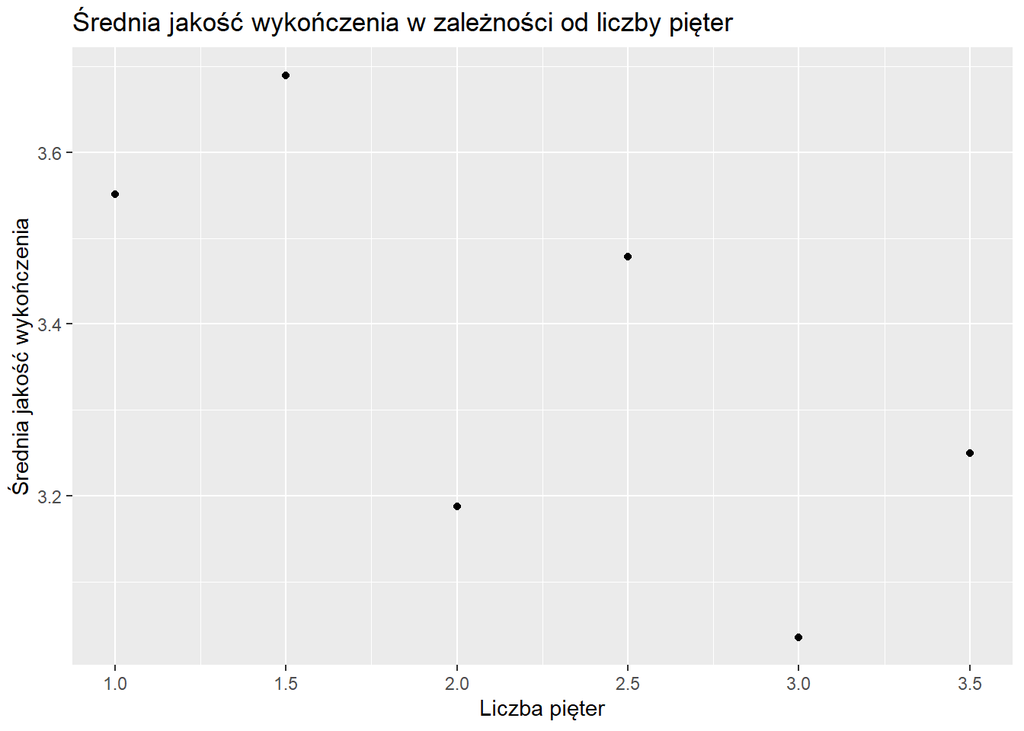

```r
zad_3 <- df %>%
  group_by(floors) %>%
  summarise(avg_condition = mean(condition))


ggplot(zad_3, aes(x = floors, y = avg_condition)) +
  geom_point() +
  labs(title = "Średnia jakość wykończenia w zależności od liczby pięter",
       x = "Liczba pięter",
       y = "Średnia jakość wykończenia")
```

**Komentarz:**

Widzimy, że średnia jakość wykończenia w budynkach o niższej liczbie pięter jest większa, jednak w obu przypadkach jest to powyżej mediany (która wynosi 3) czyli są to mieszkania w dobrych stanach.